# Spatio-temporally biased re-sampling techniques

Mariana Oliveira, Nuno Moniz, Luis Torgo, Vitor Santos Costa

# III. Spatio-Temporal Bias Resampling Strategies

## A. Algorithms

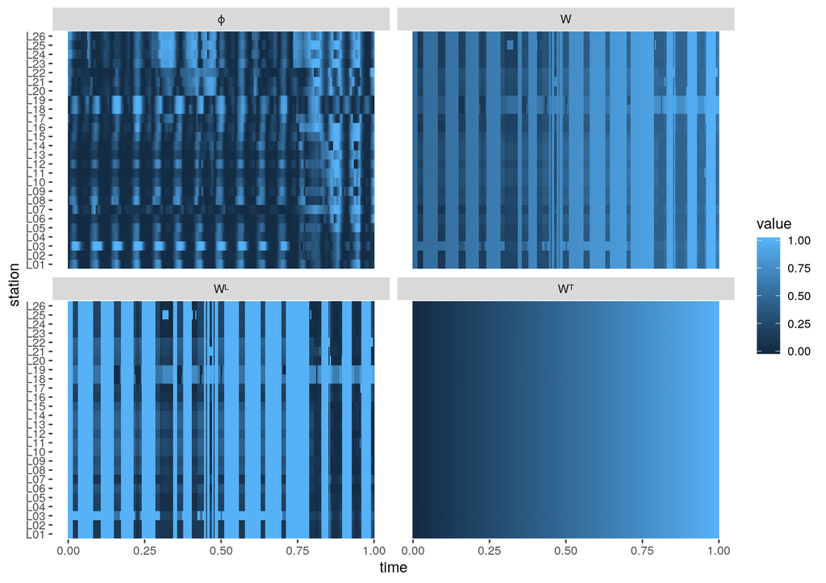

**Figure 2**: Heatmaps for data set 31, showing relevance values, $\phi$, spatial weight, $W^L$, temporal weight, $W^T$ and their combination as the spatio-temporal weight, $W$. Each cell in the heatmap corresponds to one observation at a given point in time and location

# IV. Experimental Evaluation

## A. Data and Methods

**Table I**: Real-world data sets

|  | data | timeIDs | locIDs | insts | avail | perc_extr |
| --- | --- | --- | --- | --- | --- | --- |
| 1 | 10 | 280 | 20 | 5600 | 1.00 | 7.30 |
| 2 | 20 | 105 | 72 | 7560 | 1.00 | 6.04 |
| 5 | 30 | 330 | 26 | 8580 | 1.00 | 6.25 |
| 6 | 31 | 360 | 26 | 9360 | 1.00 | 3.79 |
| 7 | 32 | 360 | 26 | 9360 | 1.00 | 2.41 |
| 13 | 40 | 4382 | 70 | 306740 | 0.49 | 7.47 |
| 14 | 50 | 6554 | 36 | 235944 | 0.64 | 3.51 |
| 15 | 51 | 6564 | 36 | 236304 | 0.66 | 5.49 |
| 16 | 52 | 6560 | 36 | 236160 | 0.68 | 8.60 |
| 17 | 53 | 6581 | 36 | 236916 | 0.68 | 3.82 |

# V. Results

## B. Tuning parameters

**Figure 5(a)**: Baseline and best $F_1^u$ result achieved for each data set. Top layers present MARS results, followed by RF and RPART. Two columns corresponds to a dataset: a baseline, in gray, and the best result. Under-sampling is shown in shades of purple, over-sampling in orange shades; darker colours indicate bias **(a)** Internally tuned parameters

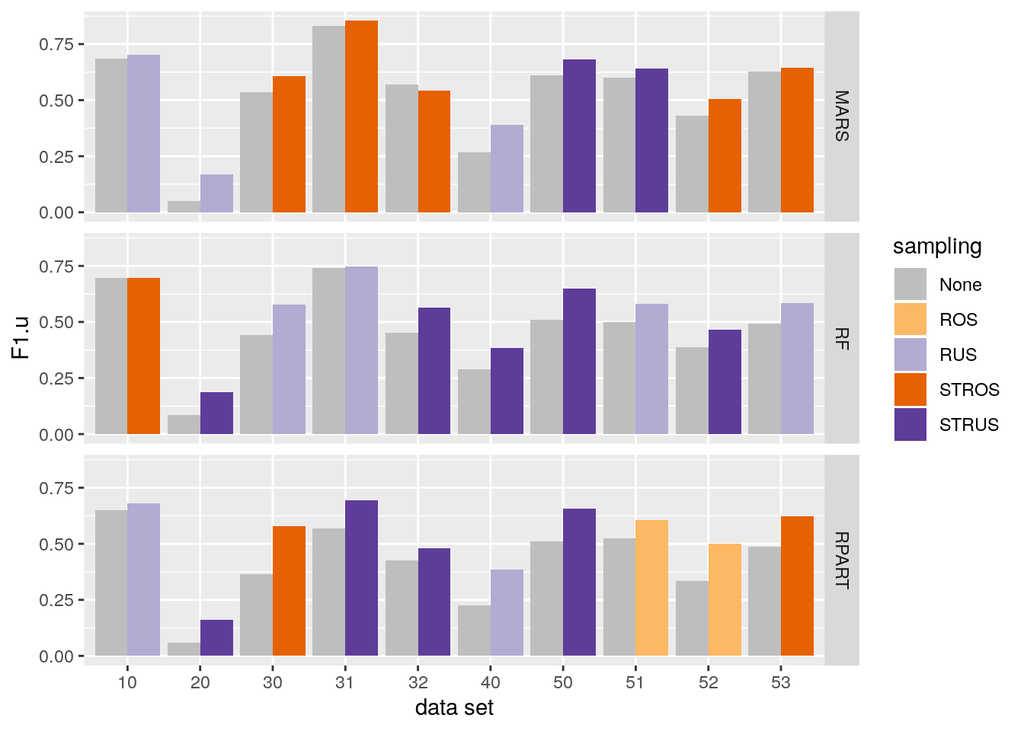

**Table III**: Average ranks of $F_1^u$ per model using tuned parameters

| model | BASELINE | ROS | STROS | RUS | STRUS |
| --- | --- | --- | --- | --- | --- |
| MARS | 4.4 | 3.2 | 2.2 | 2.5 | 2.7 |
| RF | 4.7 | 3.6 | 2.9 | 2.0 | 1.8 |
| RPART | 4.7 | 2.4 | 2.9 | 2.6 | 2.4 |

**Table IV**: Average ranks of $F_1^u$ per data set using tuned parameters

| data | BASELINE | ROS | STROS | RUS | STRUS |
| --- | --- | --- | --- | --- | --- |
| 10 | 2.67 | 2.67 | 3.33 | 2.33 | 4.00 |
| 20 | 5.00 | 3.67 | 3.33 | 1.67 | 1.33 |
| 30 | 5.00 | 3.00 | 2.00 | 2.33 | 2.67 |
| 31 | 5.00 | 2.33 | 2.33 | 2.33 | 3.00 |
| 32 | 3.33 | 4.00 | 2.00 | 3.67 | 2.00 |
| 40 | 5.00 | 3.33 | 3.33 | 1.33 | 2.00 |
| 50 | 5.00 | 3.33 | 3.00 | 2.67 | 1.00 |
| 51 | 5.00 | 2.67 | 3.00 | 2.00 | 2.33 |
| 52 | 5.00 | 3.00 | 2.67 | 2.67 | 1.67 |
| 53 | 5.00 | 2.67 | 1.67 | 2.67 | 3.00 |

## C. Fixing parameters *a priori*

Parameters fixed to $alpha$=0.5, O%=2 and U%=0.6.

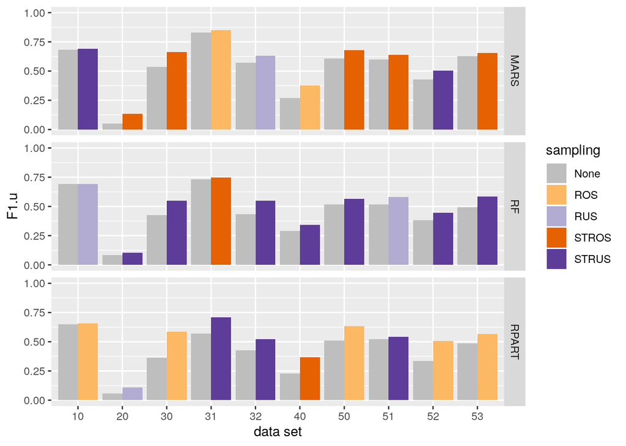

**Figure 5(b)**: Baseline and best $F_1^u$ result achieved for each data set. Top layers present MARS results, followed by RF and RPART. Two columns corresponds to a dataset: a baseline, in gray, and the best result. Under-sampling is shown in shades of purple, over-sampling in orange shades; darker colours indicate bias **(b)** Fixed parameters

**Table V**: Average ranks of $F_1^u$ per model with fixed parameters

| model | BASELINE | ROS | STROS | RUS | STRUS |
| --- | --- | --- | --- | --- | --- |
| MARS | 4.6 | 2.7 | 2.0 | 2.8 | 2.9 |
| RF | 4.6 | 3.6 | 3.1 | 2.0 | 1.7 |
| RPART | 4.4 | 2.0 | 3.1 | 2.9 | 2.6 |

**Table VI**: Average ranks of $F_1^u$ per data set with fixed parameters

| data | BASELINE | ROS | STROS | RUS | STRUS |
| --- | --- | --- | --- | --- | --- |
| 10 | 2.33 | 3.33 | 4.33 | 2.00 | 3.00 |
| 20 | 5.00 | 3.00 | 2.67 | 1.67 | 2.67 |
| 30 | 4.67 | 2.00 | 2.33 | 3.67 | 2.33 |
| 31 | 5.00 | 1.67 | 2.67 | 2.67 | 3.00 |
| 32 | 3.67 | 4.33 | 3.33 | 1.67 | 2.00 |
| 40 | 5.00 | 2.67 | 2.33 | 2.33 | 2.67 |
| 50 | 5.00 | 2.33 | 2.00 | 3.00 | 2.67 |
| 51 | 4.67 | 3.00 | 3.00 | 2.67 | 1.67 |
| 52 | 5.00 | 3.00 | 2.67 | 2.67 | 1.67 |
| 53 | 5.00 | 2.33 | 2.00 | 3.33 | 2.33 |

## D. Optimal parametrization

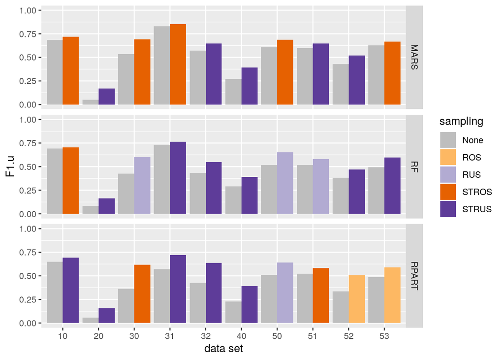

**Figure 5(c)**: Baseline and best $F_1^u$ result achieved for each data set. Top layers present MARS results, followed by RF and RPART. Two columns corresponds to a dataset: a baseline, in gray, and the best result. Under-sampling is shown in shades of purple, over-sampling in orange shades; darker colours indicate bias **(c)** Optimal parameters

**Table VII**: Average ranks of optimal $F_1^u$ results per model

| model | BASELINE | ROS | STROS | RUS | STRUS |
| --- | --- | --- | --- | --- | --- |
| MARS | 5 | 2.8 | 1.7 | 3.7 | 1.8 |
| RF | 5 | 3.7 | 2.9 | 2.0 | 1.4 |
| RPART | 5 | 2.7 | 2.2 | 3.1 | 2.0 |

**Table VIII**: Average ranks of optimal $F_1^u$ results per data set

| data | BASELINE | ROS | STROS | RUS | STRUS |
| --- | --- | --- | --- | --- | --- |
| 10 | 5 | 3.00 | 1.33 | 3.67 | 2.00 |
| 20 | 5 | 4.00 | 2.67 | 2.33 | 1.00 |
| 30 | 5 | 2.67 | 1.67 | 3.00 | 2.67 |
| 31 | 5 | 2.33 | 2.00 | 4.00 | 1.67 |
| 32 | 5 | 3.67 | 2.67 | 2.67 | 1.00 |
| 40 | 5 | 3.00 | 3.00 | 3.00 | 1.00 |
| 50 | 5 | 3.00 | 2.67 | 2.00 | 2.33 |
| 51 | 5 | 3.67 | 2.00 | 2.67 | 1.67 |
| 52 | 5 | 2.67 | 2.33 | 3.33 | 1.67 |
| 53 | 5 | 2.67 | 2.33 | 2.67 | 2.33 |

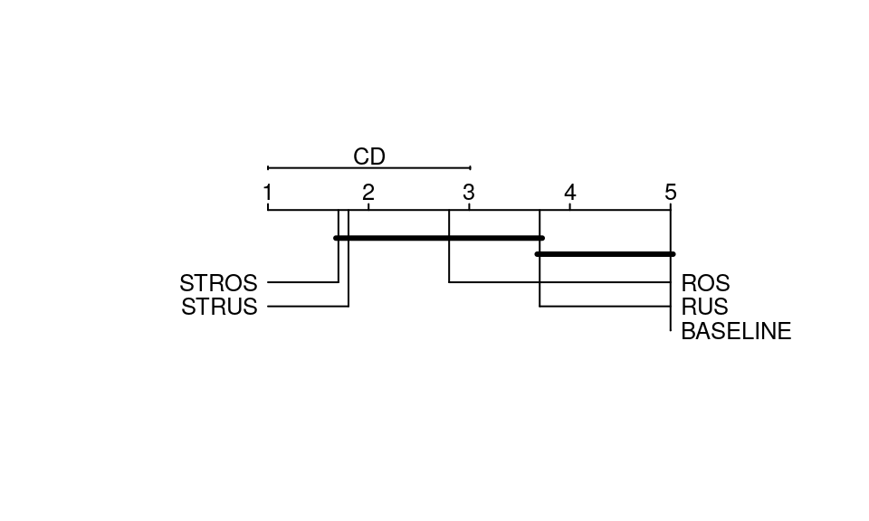

```
## MARS
```

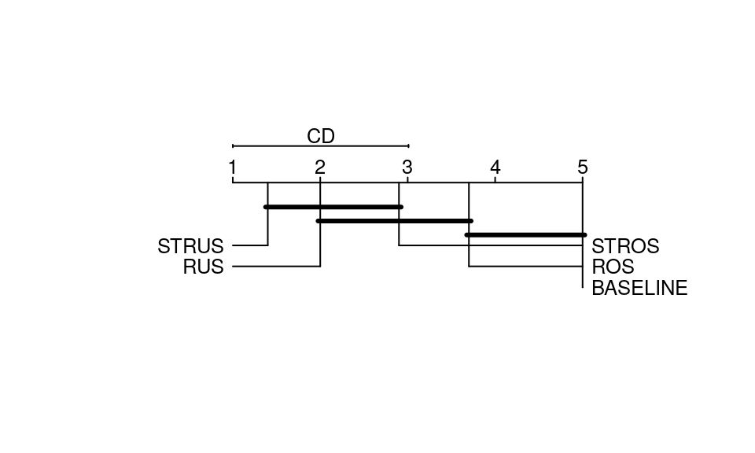

```
## RF
```

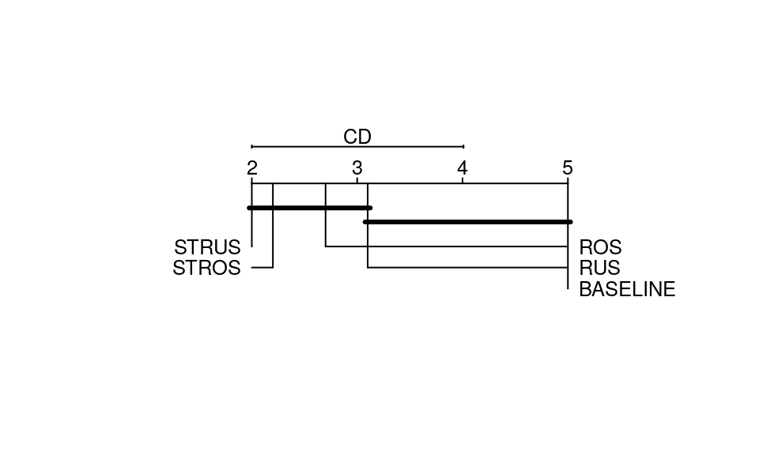

```
## RPART
```

**Figure 6**: Critical difference diagrams for different algorithms

## A. Summary of results

**Table II**: Average ranks of $F_1^u$ results

| method | BASELINE | ROS | STROS | RUS | STRUS |
| --- | --- | --- | --- | --- | --- |
| internally tuned | 4.60 | 3.07 | 2.67 | 2.37 | 2.30 |
| fixed arbitrarily a priori | 4.53 | 2.77 | 2.73 | 2.57 | 2.40 |
| optimal a posteriori | 5.00 | 3.07 | 2.27 | 2.93 | 1.73 |

## E. Parameter sensitivity analysis

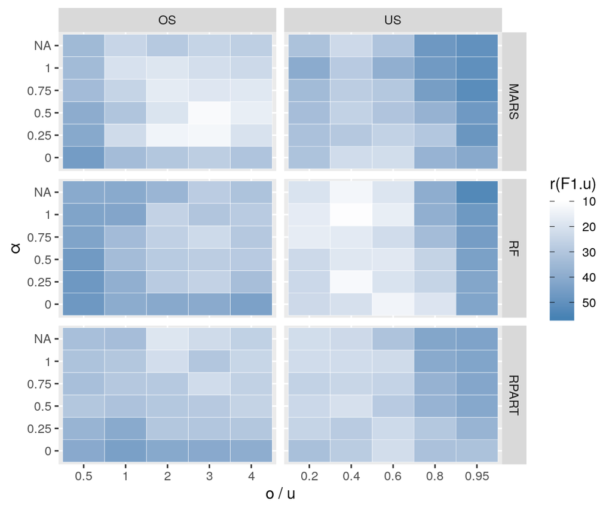

**Figure 7**: Average $F_1^u$ rank for 60(+1) different parametrizations. Ranks were calculated separately for each learning model and data set before averaging. The baseline was included in rank calculation, but excluded from the graph. Non-biased resampling is denoted by $\alpha=\mathrm{NA}$. Lower ranks correspond to better results

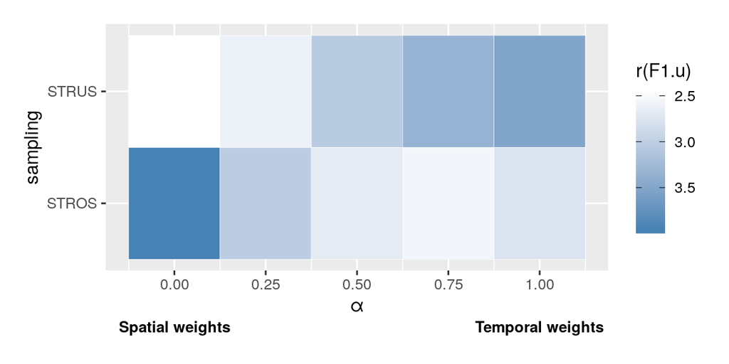

**Figure 8**: Average $F_1^u$ rank for 5 different values of $\alpha$. Ranks were calculated separately for each learning model and data set before averaging. Lower ranks correspond to better results

## F. Precision and recall trade-off

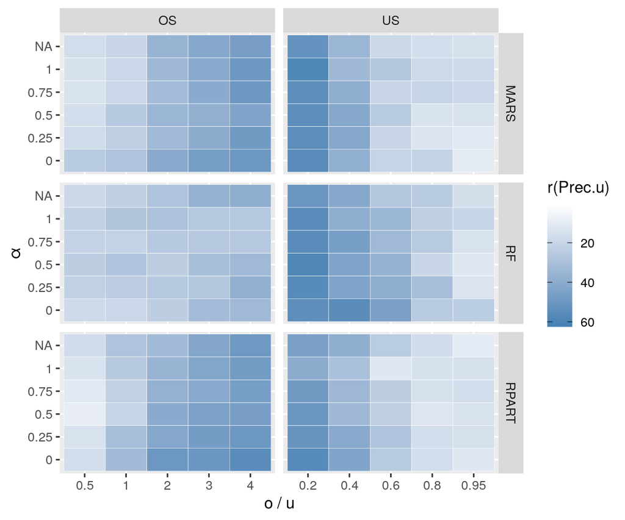

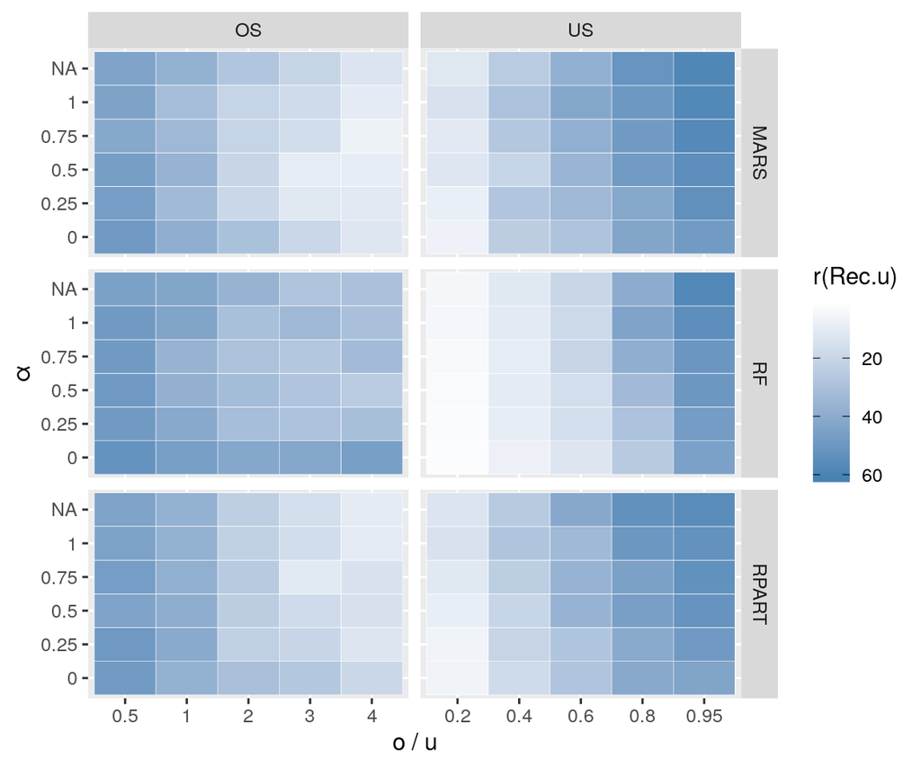

**Figure 9**: Average precision and recall rank for 60(+1) different parametrizations. Ranks were calculated separately for each learning model and data set before averaging. The baseline was included in rank calculation, but excluded from the graph. Non-biased resampling is denoted by $\alpha=\mathrm{NA}$. Lower ranks correspond to better results **(a)** $prec_{\phi}^{u}$ **(b)** $rec_{\phi}^{u}$

# Appendix

### A. Tuning parameters

**Table A.I**: Mean $F_1^u$ with internally tuned parameters

| data | model | BASELINE | ROS | RUS | STROS | STRUS |
| --- | --- | --- | --- | --- | --- | --- |
| 10 | MARS | 0.684 | 0.691 | 0.701 | 0.684 | 0.683 |
| 10 | RF | 0.695 | 0.693 | 0.690 | 0.696 | 0.694 |
| 10 | RPART | 0.651 | 0.659 | 0.679 | 0.646 | 0.647 |
| 20 | MARS | 0.052 | 0.092 | 0.168 | 0.111 | 0.145 |
| 20 | RF | 0.085 | 0.094 | 0.179 | 0.101 | 0.188 |
| 20 | RPART | 0.058 | 0.103 | 0.138 | 0.088 | 0.162 |
| 30 | MARS | 0.537 | 0.590 | 0.598 | 0.605 | 0.601 |
| 30 | RF | 0.440 | 0.469 | 0.579 | 0.457 | 0.571 |
| 30 | RPART | 0.363 | 0.578 | 0.567 | 0.579 | 0.559 |
| 31 | MARS | 0.831 | 0.852 | 0.843 | 0.854 | 0.842 |
| 31 | RF | 0.741 | 0.745 | 0.747 | 0.746 | 0.744 |
| 31 | RPART | 0.569 | 0.658 | 0.646 | 0.584 | 0.695 |
| 32 | MARS | 0.570 | 0.516 | 0.470 | 0.541 | 0.499 |
| 32 | RF | 0.452 | 0.497 | 0.498 | 0.505 | 0.563 |
| 32 | RPART | 0.425 | 0.417 | 0.441 | 0.462 | 0.479 |
| 40 | MARS | 0.269 | 0.365 | 0.389 | 0.351 | 0.383 |
| 40 | RF | 0.288 | 0.319 | 0.382 | 0.317 | 0.384 |
| 40 | RPART | 0.226 | 0.355 | 0.385 | 0.378 | 0.370 |
| 50 | MARS | 0.609 | 0.668 | 0.669 | 0.676 | 0.681 |
| 50 | RF | 0.511 | 0.542 | 0.613 | 0.550 | 0.649 |
| 50 | RPART | 0.509 | 0.645 | 0.640 | 0.629 | 0.656 |
| 51 | MARS | 0.601 | 0.620 | 0.635 | 0.632 | 0.640 |
| 51 | RF | 0.500 | 0.540 | 0.581 | 0.539 | 0.572 |
| 51 | RPART | 0.524 | 0.605 | 0.597 | 0.602 | 0.571 |
| 52 | MARS | 0.430 | 0.477 | 0.483 | 0.505 | 0.484 |
| 52 | RF | 0.387 | 0.391 | 0.460 | 0.393 | 0.465 |
| 52 | RPART | 0.335 | 0.501 | 0.494 | 0.490 | 0.499 |
| 53 | MARS | 0.626 | 0.635 | 0.630 | 0.644 | 0.630 |
| 53 | RF | 0.492 | 0.529 | 0.585 | 0.534 | 0.578 |
| 53 | RPART | 0.487 | 0.593 | 0.555 | 0.621 | 0.564 |

**Table A.II**: Mean $prec_{\phi}^{u}$ with internally tuned parameters

| data | model | BASELINE | ROS | RUS | STROS | STRUS |
| --- | --- | --- | --- | --- | --- | --- |
| 10 | MARS | 0.723 | 0.727 | 0.703 | 0.702 | 0.675 |
| 10 | RF | 0.707 | 0.700 | 0.703 | 0.703 | 0.683 |
| 10 | RPART | 0.651 | 0.654 | 0.656 | 0.677 | 0.634 |
| 20 | MARS | 0.286 | 0.236 | 0.126 | 0.247 | 0.114 |
| 20 | RF | 0.428 | 0.344 | 0.153 | 0.336 | 0.149 |
| 20 | RPART | 0.390 | 0.315 | 0.128 | 0.293 | 0.123 |
| 30 | MARS | 0.721 | 0.713 | 0.671 | 0.754 | 0.626 |
| 30 | RF | 0.694 | 0.707 | 0.680 | 0.677 | 0.658 |
| 30 | RPART | 0.656 | 0.532 | 0.525 | 0.521 | 0.509 |
| 31 | MARS | 0.856 | 0.860 | 0.847 | 0.856 | 0.836 |
| 31 | RF | 0.836 | 0.833 | 0.791 | 0.826 | 0.782 |
| 31 | RPART | 0.704 | 0.654 | 0.609 | 0.644 | 0.676 |
| 32 | MARS | 0.654 | 0.550 | 0.492 | 0.552 | 0.496 |
| 32 | RF | 0.733 | 0.673 | 0.588 | 0.676 | 0.576 |
| 32 | RPART | 0.472 | 0.440 | 0.376 | 0.529 | 0.401 |
| 40 | MARS | 0.414 | 0.397 | 0.321 | 0.377 | 0.311 |
| 40 | RF | 0.427 | 0.414 | 0.313 | 0.412 | 0.320 |
| 40 | RPART | 0.442 | 0.369 | 0.365 | 0.380 | 0.341 |
| 50 | MARS | 0.742 | 0.724 | 0.697 | 0.711 | 0.689 |
| 50 | RF | 0.669 | 0.659 | 0.651 | 0.694 | 0.661 |
| 50 | RPART | 0.726 | 0.588 | 0.576 | 0.601 | 0.616 |
| 51 | MARS | 0.667 | 0.648 | 0.651 | 0.650 | 0.652 |
| 51 | RF | 0.569 | 0.587 | 0.540 | 0.584 | 0.542 |
| 51 | RPART | 0.580 | 0.568 | 0.555 | 0.580 | 0.521 |
| 52 | MARS | 0.581 | 0.491 | 0.447 | 0.533 | 0.433 |
| 52 | RF | 0.533 | 0.510 | 0.429 | 0.520 | 0.427 |
| 52 | RPART | 0.523 | 0.502 | 0.483 | 0.475 | 0.475 |
| 53 | MARS | 0.694 | 0.658 | 0.643 | 0.656 | 0.640 |
| 53 | RF | 0.609 | 0.692 | 0.550 | 0.603 | 0.542 |
| 53 | RPART | 0.594 | 0.553 | 0.515 | 0.564 | 0.503 |

**Table A.III**: Mean $rec_{\phi}^{u}$ with internally tuned parameters

| model | data | BASELINE | ROS | RUS | STROS | STRUS |
| --- | --- | --- | --- | --- | --- | --- |
| MARS | 10 | 0.659 | 0.683 | 0.702 | 0.679 | 0.691 |
| MARS | 20 | 0.029 | 0.060 | 0.281 | 0.078 | 0.252 |
| MARS | 30 | 0.446 | 0.525 | 0.556 | 0.516 | 0.597 |
| MARS | 31 | 0.809 | 0.846 | 0.843 | 0.853 | 0.852 |
| MARS | 32 | 0.523 | 0.535 | 0.539 | 0.577 | 0.577 |
| MARS | 40 | 0.205 | 0.347 | 0.511 | 0.336 | 0.505 |
| MARS | 50 | 0.520 | 0.622 | 0.647 | 0.646 | 0.678 |
| MARS | 51 | 0.555 | 0.605 | 0.626 | 0.618 | 0.632 |
| MARS | 52 | 0.360 | 0.476 | 0.552 | 0.489 | 0.575 |
| MARS | 53 | 0.576 | 0.616 | 0.621 | 0.633 | 0.623 |
| RF | 10 | 0.684 | 0.687 | 0.702 | 0.690 | 0.706 |
| RF | 20 | 0.048 | 0.055 | 0.253 | 0.061 | 0.283 |
| RF | 30 | 0.344 | 0.369 | 0.536 | 0.364 | 0.535 |
| RF | 31 | 0.674 | 0.683 | 0.716 | 0.691 | 0.716 |
| RF | 32 | 0.370 | 0.430 | 0.585 | 0.425 | 0.644 |
| RF | 40 | 0.226 | 0.267 | 0.512 | 0.266 | 0.496 |
| RF | 50 | 0.416 | 0.462 | 0.620 | 0.471 | 0.644 |
| RF | 51 | 0.469 | 0.524 | 0.643 | 0.520 | 0.621 |
| RF | 52 | 0.321 | 0.331 | 0.517 | 0.332 | 0.542 |
| RF | 53 | 0.430 | 0.484 | 0.635 | 0.493 | 0.639 |
| RPART | 10 | 0.655 | 0.669 | 0.710 | 0.633 | 0.668 |
| RPART | 20 | 0.032 | 0.068 | 0.224 | 0.058 | 0.275 |
| RPART | 30 | 0.290 | 0.687 | 0.675 | 0.690 | 0.674 |
| RPART | 31 | 0.537 | 0.679 | 0.706 | 0.596 | 0.759 |
| RPART | 32 | 0.422 | 0.524 | 0.722 | 0.524 | 0.727 |
| RPART | 40 | 0.162 | 0.366 | 0.427 | 0.386 | 0.450 |
| RPART | 50 | 0.430 | 0.718 | 0.733 | 0.679 | 0.708 |
| RPART | 51 | 0.515 | 0.658 | 0.653 | 0.640 | 0.658 |
| RPART | 52 | 0.274 | 0.517 | 0.536 | 0.536 | 0.562 |
| RPART | 53 | 0.460 | 0.658 | 0.684 | 0.717 | 0.659 |

### B. Fixed parameters

**Table B.I**: Mean $F_1^u$ with fixed parameters

| model | data | BASELINE | ROS | RUS | STROS | STRUS |
| --- | --- | --- | --- | --- | --- | --- |
| MARS | 10 | 0.684 | 0.684 | 0.691 | 0.678 | 0.693 |
| MARS | 20 | 0.052 | 0.094 | 0.104 | 0.134 | 0.088 |
| MARS | 30 | 0.537 | 0.595 | 0.555 | 0.662 | 0.570 |
| MARS | 31 | 0.831 | 0.848 | 0.847 | 0.846 | 0.840 |
| MARS | 32 | 0.570 | 0.508 | 0.629 | 0.584 | 0.533 |
| MARS | 40 | 0.269 | 0.378 | 0.323 | 0.352 | 0.316 |
| MARS | 50 | 0.609 | 0.668 | 0.642 | 0.681 | 0.644 |
| MARS | 51 | 0.601 | 0.626 | 0.625 | 0.637 | 0.626 |
| MARS | 52 | 0.430 | 0.480 | 0.492 | 0.483 | 0.504 |
| MARS | 53 | 0.626 | 0.639 | 0.632 | 0.656 | 0.638 |
| RF | 10 | 0.694 | 0.690 | 0.694 | 0.693 | 0.692 |
| RF | 20 | 0.085 | 0.093 | 0.099 | 0.096 | 0.102 |
| RF | 30 | 0.426 | 0.482 | 0.489 | 0.475 | 0.547 |
| RF | 31 | 0.732 | 0.745 | 0.744 | 0.749 | 0.740 |
| RF | 32 | 0.434 | 0.490 | 0.518 | 0.470 | 0.548 |
| RF | 40 | 0.290 | 0.320 | 0.341 | 0.317 | 0.344 |
| RF | 50 | 0.515 | 0.543 | 0.560 | 0.558 | 0.566 |
| RF | 51 | 0.515 | 0.545 | 0.580 | 0.547 | 0.563 |
| RF | 52 | 0.383 | 0.393 | 0.418 | 0.402 | 0.445 |
| RF | 53 | 0.495 | 0.526 | 0.548 | 0.540 | 0.584 |
| RPART | 10 | 0.651 | 0.658 | 0.655 | 0.638 | 0.651 |
| RPART | 20 | 0.058 | 0.106 | 0.110 | 0.087 | 0.088 |
| RPART | 30 | 0.363 | 0.584 | 0.324 | 0.568 | 0.453 |
| RPART | 31 | 0.569 | 0.627 | 0.625 | 0.598 | 0.711 |
| RPART | 32 | 0.425 | 0.403 | 0.459 | 0.413 | 0.522 |
| RPART | 40 | 0.226 | 0.349 | 0.357 | 0.366 | 0.353 |
| RPART | 50 | 0.509 | 0.633 | 0.547 | 0.623 | 0.542 |
| RPART | 51 | 0.524 | 0.535 | 0.532 | 0.499 | 0.544 |
| RPART | 52 | 0.335 | 0.507 | 0.439 | 0.505 | 0.476 |
| RPART | 53 | 0.487 | 0.568 | 0.512 | 0.556 | 0.530 |

**Table B.II**: Mean $prec_{\phi}^{u}$ with fixed parameters

| model | data | BASELINE | ROS | RUS | STROS | STRUS |
| --- | --- | --- | --- | --- | --- | --- |
| MARS | 10 | 0.723 | 0.694 | 0.708 | 0.677 | 0.707 |
| MARS | 20 | 0.286 | 0.199 | 0.351 | 0.273 | 0.413 |
| MARS | 30 | 0.721 | 0.721 | 0.699 | 0.772 | 0.690 |
| MARS | 31 | 0.856 | 0.849 | 0.854 | 0.832 | 0.843 |
| MARS | 32 | 0.654 | 0.502 | 0.686 | 0.586 | 0.555 |
| MARS | 40 | 0.414 | 0.391 | 0.401 | 0.357 | 0.403 |
| MARS | 50 | 0.742 | 0.724 | 0.737 | 0.713 | 0.736 |
| MARS | 51 | 0.667 | 0.636 | 0.661 | 0.653 | 0.651 |
| MARS | 52 | 0.581 | 0.488 | 0.587 | 0.520 | 0.581 |
| MARS | 53 | 0.694 | 0.663 | 0.676 | 0.654 | 0.672 |
| RF | 10 | 0.704 | 0.693 | 0.689 | 0.697 | 0.684 |
| RF | 20 | 0.444 | 0.354 | 0.467 | 0.323 | 0.321 |
| RF | 30 | 0.643 | 0.799 | 0.695 | 0.695 | 0.695 |
| RF | 31 | 0.834 | 0.829 | 0.800 | 0.828 | 0.810 |
| RF | 32 | 0.754 | 0.661 | 0.714 | 0.642 | 0.796 |
| RF | 40 | 0.430 | 0.401 | 0.402 | 0.409 | 0.393 |
| RF | 50 | 0.773 | 0.662 | 0.751 | 0.762 | 0.641 |
| RF | 51 | 0.582 | 0.583 | 0.585 | 0.589 | 0.559 |
| RF | 52 | 0.511 | 0.518 | 0.510 | 0.529 | 0.508 |
| RF | 53 | 0.609 | 0.616 | 0.632 | 0.598 | 0.628 |
| RPART | 10 | 0.651 | 0.650 | 0.650 | 0.624 | 0.658 |
| RPART | 20 | 0.390 | 0.302 | 0.318 | 0.268 | 0.303 |
| RPART | 30 | 0.656 | 0.535 | 0.476 | 0.500 | 0.530 |
| RPART | 31 | 0.704 | 0.546 | 0.617 | 0.543 | 0.662 |
| RPART | 32 | 0.472 | 0.461 | 0.542 | 0.460 | 0.669 |
| RPART | 40 | 0.442 | 0.361 | 0.391 | 0.385 | 0.390 |
| RPART | 50 | 0.726 | 0.567 | 0.647 | 0.551 | 0.576 |
| RPART | 51 | 0.580 | 0.485 | 0.560 | 0.459 | 0.531 |
| RPART | 52 | 0.523 | 0.516 | 0.533 | 0.508 | 0.538 |
| RPART | 53 | 0.594 | 0.601 | 0.569 | 0.505 | 0.510 |

**Table B.III**: Mean $rec_{\phi}^{u}$ with fixed parameters

| model | data | BASELINE | ROS | RUS | STROS | STRUS |
| --- | --- | --- | --- | --- | --- | --- |
| MARS | 10 | 0.659 | 0.690 | 0.684 | 0.687 | 0.689 |
| MARS | 20 | 0.029 | 0.065 | 0.065 | 0.094 | 0.051 |
| MARS | 30 | 0.446 | 0.526 | 0.466 | 0.585 | 0.497 |
| MARS | 31 | 0.809 | 0.849 | 0.844 | 0.863 | 0.841 |
| MARS | 32 | 0.523 | 0.556 | 0.597 | 0.613 | 0.590 |
| MARS | 40 | 0.205 | 0.367 | 0.291 | 0.352 | 0.263 |
| MARS | 50 | 0.520 | 0.622 | 0.571 | 0.652 | 0.576 |
| MARS | 51 | 0.555 | 0.624 | 0.597 | 0.626 | 0.606 |
| MARS | 52 | 0.360 | 0.484 | 0.439 | 0.460 | 0.460 |
| MARS | 53 | 0.576 | 0.619 | 0.596 | 0.666 | 0.610 |
| RF | 10 | 0.684 | 0.688 | 0.700 | 0.691 | 0.701 |
| RF | 20 | 0.048 | 0.054 | 0.058 | 0.058 | 0.063 |
| RF | 30 | 0.335 | 0.390 | 0.397 | 0.385 | 0.463 |
| RF | 31 | 0.662 | 0.685 | 0.708 | 0.694 | 0.692 |
| RF | 32 | 0.358 | 0.419 | 0.438 | 0.402 | 0.481 |
| RF | 40 | 0.228 | 0.290 | 0.311 | 0.265 | 0.325 |
| RF | 50 | 0.419 | 0.462 | 0.487 | 0.476 | 0.509 |
| RF | 51 | 0.486 | 0.537 | 0.590 | 0.535 | 0.590 |
| RF | 52 | 0.319 | 0.334 | 0.363 | 0.338 | 0.404 |
| RF | 53 | 0.427 | 0.481 | 0.518 | 0.503 | 0.560 |
| RPART | 10 | 0.655 | 0.671 | 0.662 | 0.672 | 0.648 |
| RPART | 20 | 0.032 | 0.074 | 0.083 | 0.055 | 0.063 |
| RPART | 30 | 0.290 | 0.695 | 0.342 | 0.710 | 0.496 |
| RPART | 31 | 0.537 | 0.827 | 0.661 | 0.774 | 0.794 |
| RPART | 32 | 0.422 | 0.526 | 0.422 | 0.537 | 0.445 |
| RPART | 40 | 0.162 | 0.361 | 0.333 | 0.365 | 0.358 |
| RPART | 50 | 0.430 | 0.728 | 0.554 | 0.732 | 0.632 |
| RPART | 51 | 0.515 | 0.653 | 0.572 | 0.642 | 0.614 |
| RPART | 52 | 0.274 | 0.519 | 0.407 | 0.512 | 0.449 |
| RPART | 53 | 0.460 | 0.642 | 0.566 | 0.732 | 0.700 |

### C. Optimal parameters

**Table C.I**: Mean $F_1^u$ with optimal parameters

| model | data | sampling | cperc | alpha | F1.u |
| --- | --- | --- | --- | --- | --- |
| MARS | 10 | STROS | 3.00 | 0.50 | 0.719 |
| MARS | 20 | STRUS | 0.20 | 0.00 | 0.171 |
| MARS | 30 | STROS | 4.00 | 0.50 | 0.689 |
| MARS | 31 | STROS | 0.50 | 1.00 | 0.853 |
| MARS | 32 | STRUS | 0.95 | 0.00 | 0.647 |
| MARS | 40 | STRUS | 0.20 | 0.25 | 0.394 |
| MARS | 50 | STROS | 3.00 | 0.25 | 0.687 |
| MARS | 51 | STRUS | 0.60 | 0.00 | 0.647 |
| MARS | 52 | STRUS | 0.60 | 0.25 | 0.519 |
| MARS | 53 | STROS | 3.00 | 0.75 | 0.665 |
| RF | 10 | STROS | 4.00 | 0.50 | 0.705 |
| RF | 20 | STRUS | 0.20 | 0.75 | 0.164 |
| RF | 30 | RUS | 0.20 | NA | 0.599 |
| RF | 31 | STRUS | 0.20 | 1.00 | 0.764 |
| RF | 32 | STRUS | 0.60 | 0.50 | 0.548 |
| RF | 40 | STRUS | 0.20 | 0.25 | 0.391 |
| RF | 50 | RUS | 0.20 | NA | 0.654 |
| RF | 51 | RUS | 0.60 | NA | 0.580 |
| RF | 52 | STRUS | 0.40 | 0.00 | 0.470 |
| RF | 53 | STRUS | 0.40 | 0.00 | 0.596 |
| RPART | 10 | STRUS | 0.60 | 1.00 | 0.692 |
| RPART | 20 | STRUS | 0.20 | 0.00 | 0.156 |
| RPART | 30 | STROS | 4.00 | 0.50 | 0.619 |
| RPART | 31 | STRUS | 0.60 | 0.00 | 0.719 |
| RPART | 32 | STRUS | 0.60 | 0.00 | 0.637 |
| RPART | 40 | STRUS | 0.20 | 0.75 | 0.389 |
| RPART | 50 | RUS | 0.20 | NA | 0.641 |
| RPART | 51 | STROS | 0.50 | 1.00 | 0.584 |
| RPART | 52 | ROS | 2.00 | NA | 0.507 |
| RPART | 53 | ROS | 1.00 | NA | 0.590 |

**Table C.II**: Mean $prec_{\phi}^{u}$ with optimal parameters

| model | data | sampling | cperc | alpha | prec.u |
| --- | --- | --- | --- | --- | --- |
| MARS | 10 | STROS | 3.00 | 0.50 | 0.700 |
| MARS | 20 | STRUS | 0.20 | 0.00 | 0.172 |
| MARS | 30 | STROS | 4.00 | 0.50 | 0.762 |
| MARS | 31 | STROS | 0.50 | 1.00 | 0.863 |
| MARS | 32 | STRUS | 0.95 | 0.00 | 0.738 |
| MARS | 40 | STRUS | 0.20 | 0.25 | 0.339 |
| MARS | 50 | STROS | 3.00 | 0.25 | 0.696 |
| MARS | 51 | STRUS | 0.60 | 0.00 | 0.669 |
| MARS | 52 | STRUS | 0.60 | 0.25 | 0.586 |
| MARS | 53 | STROS | 3.00 | 0.75 | 0.649 |
| RF | 10 | STROS | 4.00 | 0.50 | 0.708 |
| RF | 20 | STRUS | 0.20 | 0.75 | 0.236 |
| RF | 30 | RUS | 0.20 | NA | 0.726 |
| RF | 31 | STRUS | 0.20 | 1.00 | 0.750 |
| RF | 32 | STRUS | 0.60 | 0.50 | 0.796 |
| RF | 40 | STRUS | 0.20 | 0.25 | 0.322 |
| RF | 50 | RUS | 0.20 | NA | 0.644 |
| RF | 51 | RUS | 0.60 | NA | 0.585 |
| RF | 52 | STRUS | 0.40 | 0.00 | 0.470 |
| RF | 53 | STRUS | 0.40 | 0.00 | 0.530 |
| RPART | 10 | STRUS | 0.60 | 1.00 | 0.686 |
| RPART | 20 | STRUS | 0.20 | 0.00 | 0.203 |
| RPART | 30 | STROS | 4.00 | 0.50 | 0.532 |
| RPART | 31 | STRUS | 0.60 | 0.00 | 0.696 |
| RPART | 32 | STRUS | 0.60 | 0.00 | 0.704 |
| RPART | 40 | STRUS | 0.20 | 0.75 | 0.368 |
| RPART | 50 | RUS | 0.20 | NA | 0.626 |
| RPART | 51 | STROS | 0.50 | 1.00 | 0.594 |
| RPART | 52 | ROS | 2.00 | NA | 0.516 |
| RPART | 53 | ROS | 1.00 | NA | 0.525 |

**Table C.III**: Mean $rec_{\phi}^{u}$ with optimal parameters

| model | data | sampling | cperc | alpha | rec.u |
| --- | --- | --- | --- | --- | --- |
| MARS | 10 | STROS | 3.00 | 0.50 | 0.740 |
| MARS | 20 | STRUS | 0.20 | 0.00 | 0.184 |
| MARS | 30 | STROS | 4.00 | 0.50 | 0.636 |
| MARS | 31 | STROS | 0.50 | 1.00 | 0.845 |
| MARS | 32 | STRUS | 0.95 | 0.00 | 0.585 |
| MARS | 40 | STRUS | 0.20 | 0.25 | 0.476 |
| MARS | 50 | STROS | 3.00 | 0.25 | 0.679 |
| MARS | 51 | STRUS | 0.60 | 0.00 | 0.629 |
| MARS | 52 | STRUS | 0.60 | 0.25 | 0.482 |
| MARS | 53 | STROS | 3.00 | 0.75 | 0.700 |
| RF | 10 | STROS | 4.00 | 0.50 | 0.702 |
| RF | 20 | STRUS | 0.20 | 0.75 | 0.139 |
| RF | 30 | RUS | 0.20 | NA | 0.562 |
| RF | 31 | STRUS | 0.20 | 1.00 | 0.784 |
| RF | 32 | STRUS | 0.60 | 0.50 | 0.481 |
| RF | 40 | STRUS | 0.20 | 0.25 | 0.505 |
| RF | 50 | RUS | 0.20 | NA | 0.670 |
| RF | 51 | RUS | 0.60 | NA | 0.590 |
| RF | 52 | STRUS | 0.40 | 0.00 | 0.481 |
| RF | 53 | STRUS | 0.40 | 0.00 | 0.721 |
| RPART | 10 | STRUS | 0.60 | 1.00 | 0.703 |
| RPART | 20 | STRUS | 0.20 | 0.00 | 0.172 |
| RPART | 30 | STROS | 4.00 | 0.50 | 0.783 |
| RPART | 31 | STRUS | 0.60 | 0.00 | 0.757 |
| RPART | 32 | STRUS | 0.60 | 0.00 | 0.621 |
| RPART | 40 | STRUS | 0.20 | 0.75 | 0.436 |
| RPART | 50 | RUS | 0.20 | NA | 0.686 |
| RPART | 51 | STROS | 0.50 | 1.00 | 0.610 |
| RPART | 52 | ROS | 2.00 | NA | 0.519 |
| RPART | 53 | ROS | 1.00 | NA | 0.758 |

### E. Parameter sensitivity analysis

**Table E.I**: Mean rank with each set of parameters

| model | sampling | cperc | alpha | F1.u_rank_avg | prec.u_rank_avg | rec.u_rank_avg |
| --- | --- | --- | --- | --- | --- | --- |
| MARS | BASELINE | NA | NA | 52.0 | 13.9 | 59.0 |
| MARS | ROS | 0.50 | NA | 34.8 | 16.5 | 44.4 |
| MARS | ROS | 1.00 | NA | 24.7 | 19.9 | 37.6 |
| MARS | ROS | 2.00 | NA | 29.1 | 36.0 | 27.6 |
| MARS | ROS | 3.00 | NA | 25.2 | 42.0 | 20.5 |
| MARS | ROS | 4.00 | NA | 27.0 | 46.6 | 13.3 |
| MARS | RUS | 0.20 | NA | 31.8 | 52.4 | 11.9 |
| MARS | RUS | 0.40 | NA | 23.2 | 35.1 | 25.1 |
| MARS | RUS | 0.60 | NA | 30.9 | 18.9 | 38.0 |
| MARS | RUS | 0.80 | NA | 47.3 | 16.1 | 51.7 |
| MARS | RUS | 0.95 | NA | 50.0 | 15.3 | 58.5 |
| MARS | STROS | 0.50 | 0.00 | 45.8 | 24.8 | 49.1 |
| MARS | STROS | 0.50 | 0.25 | 41.1 | 17.7 | 47.1 |
| MARS | STROS | 0.50 | 0.50 | 39.7 | 16.2 | 47.0 |
| MARS | STROS | 0.50 | 0.75 | 34.1 | 14.5 | 42.1 |
| MARS | STROS | 0.50 | 1.00 | 34.3 | 14.7 | 44.7 |
| MARS | STROS | 1.00 | 0.00 | 33.8 | 28.7 | 38.8 |
| MARS | STROS | 1.00 | 0.25 | 22.7 | 23.2 | 33.0 |
| MARS | STROS | 1.00 | 0.50 | 30.7 | 25.8 | 36.4 |
| MARS | STROS | 1.00 | 0.75 | 25.2 | 19.5 | 33.9 |
| MARS | STROS | 1.00 | 1.00 | 20.4 | 19.4 | 31.5 |
| MARS | STROS | 2.00 | 0.00 | 30.0 | 41.2 | 30.0 |
| MARS | STROS | 2.00 | 0.25 | 13.8 | 33.8 | 19.6 |
| MARS | STROS | 2.00 | 0.50 | 19.6 | 35.1 | 20.1 |
| MARS | STROS | 2.00 | 0.75 | 17.1 | 32.2 | 20.9 |
| MARS | STROS | 2.00 | 1.00 | 18.9 | 34.0 | 20.9 |
| MARS | STROS | 3.00 | 0.00 | 27.4 | 47.0 | 19.4 |
| MARS | STROS | 3.00 | 0.25 | 12.8 | 39.7 | 11.5 |
| MARS | STROS | 3.00 | 0.50 | 11.7 | 38.2 | 9.8 |
| MARS | STROS | 3.00 | 0.75 | 18.6 | 40.4 | 16.6 |

[output cut: 153 more lines]

### F. Figures in presentation

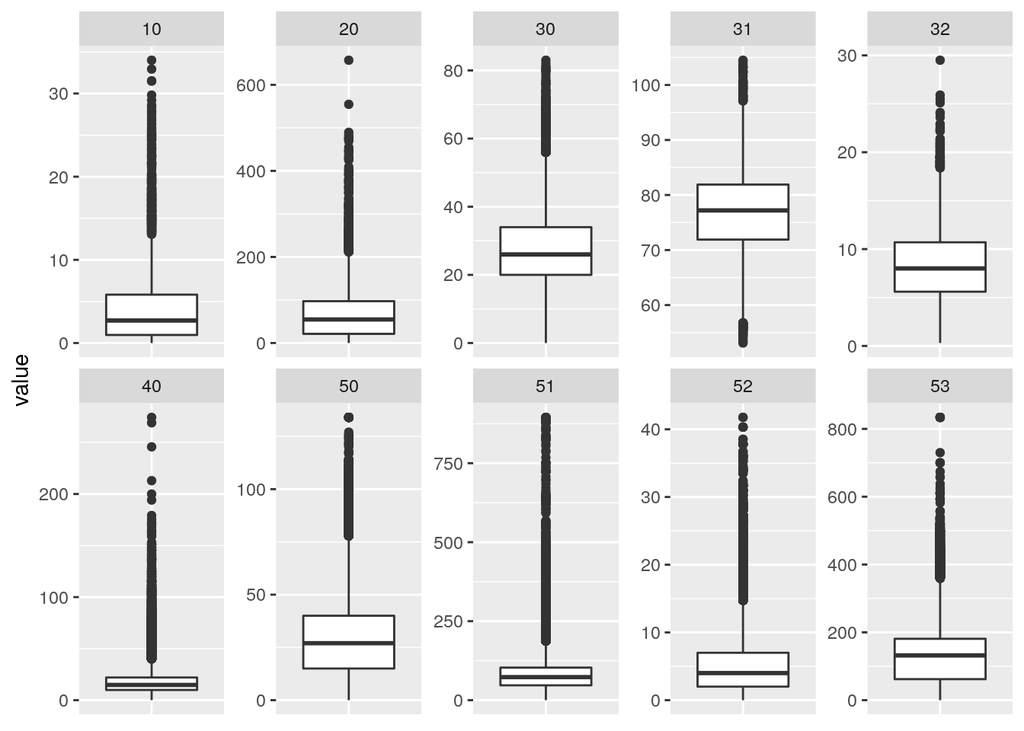

**Figure F.1**: Boxplot of target variables

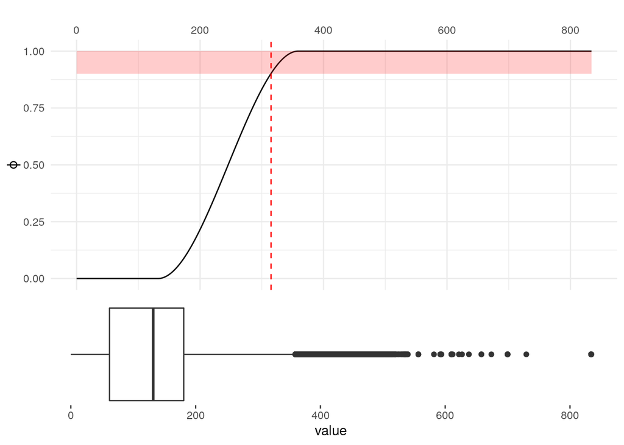

**Figure F.2**: Relevance function and boxplot for PM 2.5 pollution levels in Beijing

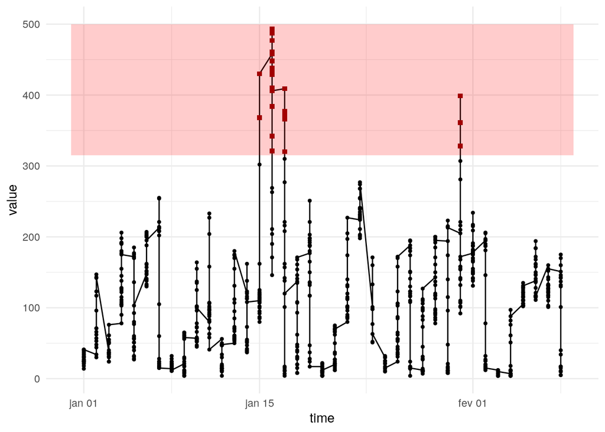

**Figure F.3**: Time series of PM 2.5 pollution levels at a Beijing station

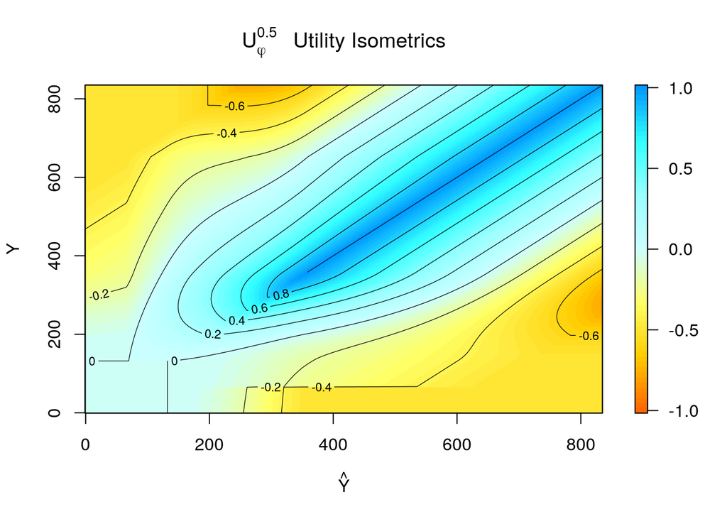

**Figure F.4**: Utility isometrics for relevance function in Fig. F.2